# Your Turn: Lab exercise

```r
library(tidyverse)
library(broom)
install.packages("remotes")
library(remotes)
remotes::install_github("njtierney/broomstick")
```

```r
library(broomstick)
library(rpart)
library(rpart.plot)
library(here)
```

How could you predict the log scaled price it would go for at auction?

The data set we are using is the paris paintings dataset we discussed in the linear models lecture. The data dictionary is available here: http://www2.stat.duke.edu/~cr173/Sta112_Fa16/data/paris_paintings.html

```r
pp <- read_csv(here::here("data/paris-paintings.csv"), na = c("-", "n/a", "-", ""))
pp
```

```
## # A tibble: 3,393 x 61
##    name  sale  lot   position dealer  year origin_author origin_cat school_pntg
##    <chr> <chr> <chr>    <dbl> <chr>  <dbl> <chr>         <chr>      <chr>
##  1 L176… L1764 2       0.0328 L       1764 F             O          F
##  2 L176… L1764 3       0.0492 L       1764 I             O          I
##  3 L176… L1764 4       0.0656 L       1764 X             O          D/FL
##  4 L176… L1764 5       0.0820 L       1764 F             O          F
##  5 L176… L1764 5       0.0820 L       1764 F             O          F
##  6 L176… L1764 6       0.0984 L       1764 X             O          I
##  7 L176… L1764 7       0.115  L       1764 F             O          F
##  8 L176… L1764 7       0.115  L       1764 F             O          F
##  9 L176… L1764 8       0.131  L       1764 X             O          I
## 10 L176… L1764 9       0.148  L       1764 D/FL          O          D/FL
## # … with 3,383 more rows, and 52 more variables: diff_origin <dbl>,
## #   logprice <dbl>, price <dbl>, count <dbl>, subject <chr>,
## #   authorstandard <chr>, artistliving <dbl>, authorstyle <chr>, author <chr>,
## #   winningbidder <chr>, winningbiddertype <chr>, endbuyer <chr>, Interm <dbl>,
## #   type_intermed <chr>, Height_in <dbl>, Width_in <dbl>, Surface_Rect <dbl>,
## #   Diam_in <dbl>, Surface_Rnd <dbl>, Shape <chr>, Surface <dbl>,
## #   material <chr>, mat <chr>, materialCat <chr>, quantity <dbl>,
## #   nfigures <dbl>, engraved <dbl>, original <dbl>, prevcoll <dbl>,
## #   othartist <dbl>, paired <dbl>, figures <dbl>, finished <dbl>,
## #   lrgfont <dbl>, relig <dbl>, landsALL <dbl>, lands_sc <dbl>,
## #   lands_elem <dbl>, lands_figs <dbl>, lands_ment <dbl>, arch <dbl>,
## #   mytho <dbl>, peasant <dbl>, othgenre <dbl>, singlefig <dbl>,
## #   portrait <dbl>, still_life <dbl>, discauth <dbl>, history <dbl>,
## #   allegory <dbl>, pastorale <dbl>, other <dbl>
```

## Reminder linear models

```r
pp_lm <- lm(logprice ~ Height_in + Width_in, data = pp)

pp_lm_aug <- augment(pp_lm)
```

## Using a regression tree

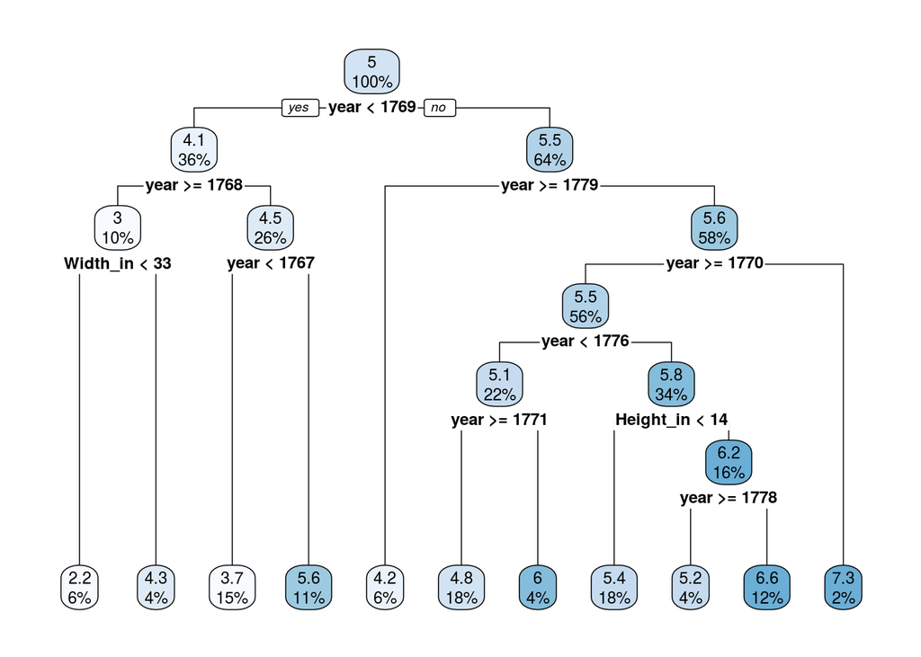

```r
pp_rp <- rpart(logprice ~ Height_in + Width_in + year, data = pp)
pp_rp_aug <- augment(pp_rp)
library(rpart.plot)
rpart.plot(pp_rp)
```

### Your turn plot residuals vs fitted values for both models, how do they compare?

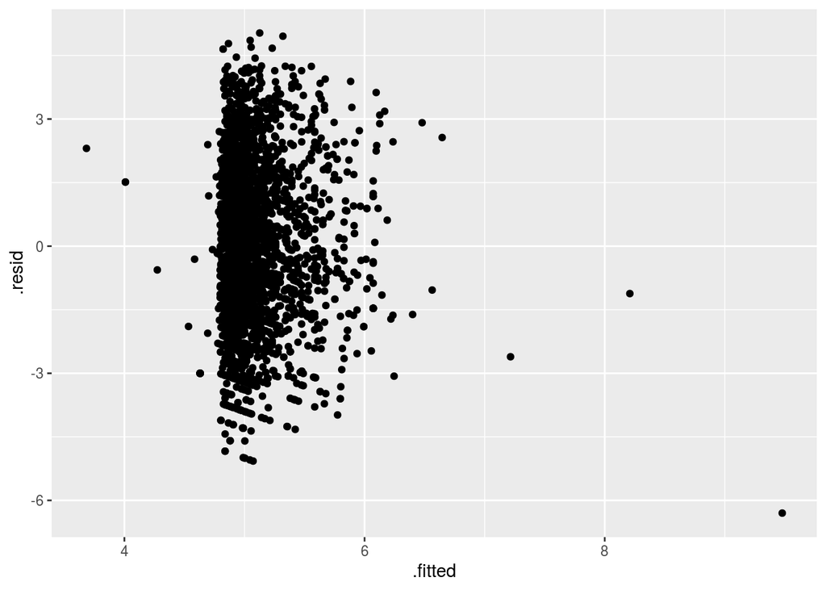

```r
pp_lm_aug %>% ggplot(aes(x = .fitted, y = .resid)) +
   geom_point()
```

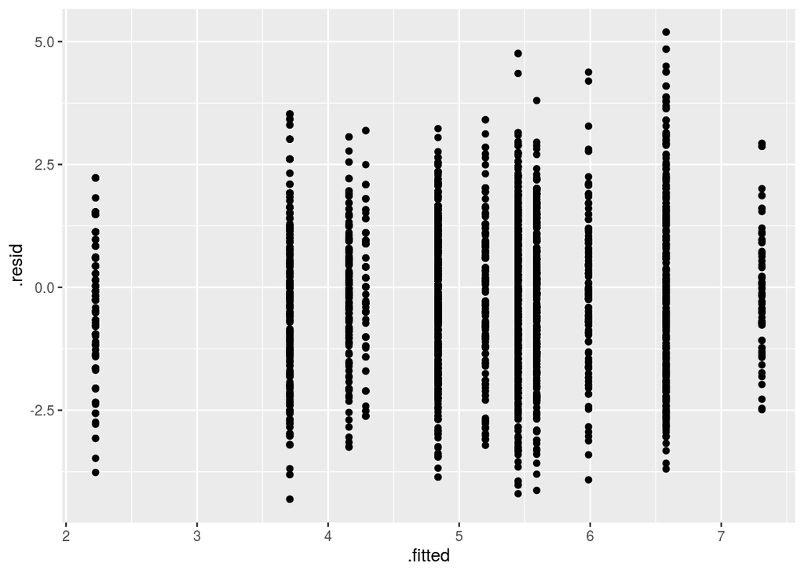

```r
pp_rp_aug %>% ggplot(aes(x = .fitted, y = .resid)) +
   geom_point()
```

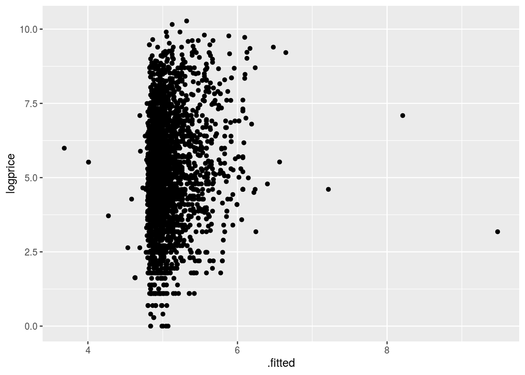

```r
# also, look at fitted vs predicted
pp_lm_aug %>% ggplot(aes(x = .fitted, y = logprice)) +
   geom_point()
```

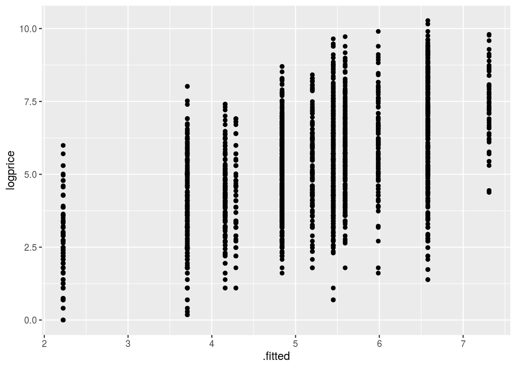

```r
pp_rp_aug %>% ggplot(aes(x = .fitted, y = logprice)) +
   geom_point()
```

### Figuring out what drives price

Describe why we’ve subsetted the data (to avoid perfect predictors?)

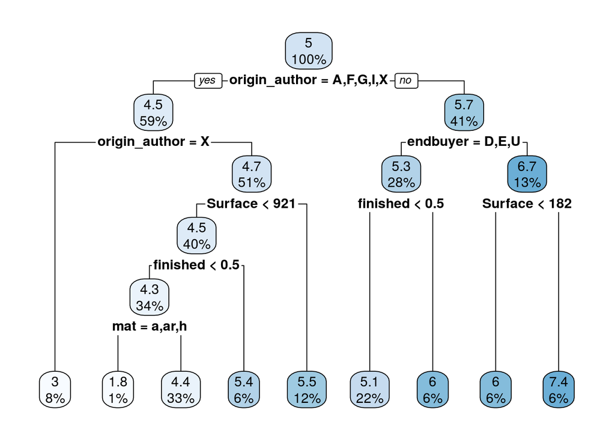

```r
pp_rp_all <- rpart(logprice ~ ., data = select(pp,
                                               logprice,
                                               origin_author,
                                               school_pntg,
                                               artistliving,
                                               authorstyle,
                                               endbuyer,
                                               Height_in:Surface,
                                               mat,
                                               engraved:finished,
                                               relig,
                                               landsALL,
                                               arch:other))

rpart.plot(pp_rp_all, roundint = FALSE)
```

What do the residuals and goodness of fit look like?

How does variable importance work?

> After calculating all the potential splits, it gives a score to each variable for the number of times it was used in splitting

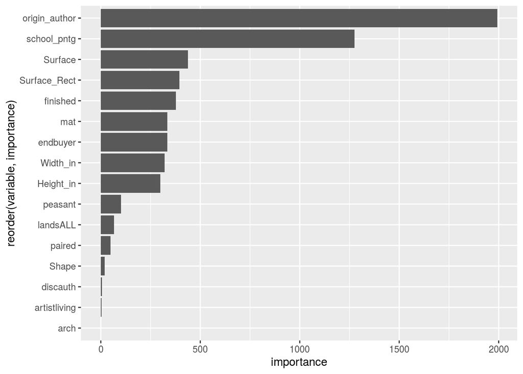

```r
tidy(pp_rp_all) %>%
  ggplot(aes(x = importance,
             y = reorder(variable, importance))) +
  geom_col()
```

### Price prediction

```r
# use tidy to find top3 most important vars (yours might vary from the solution)
tidy(pp_rp_all)
```

```
## # A tibble: 16 x 2
##    variable      importance
##    <chr>              <dbl>
##  1 origin_author   1994.
##  2 school_pntg     1275.
##  3 Surface          438.
##  4 Surface_Rect     394.
##  5 finished         378.
##  6 mat              335.
##  7 endbuyer         333.
##  8 Width_in         320.
##  9 Height_in        299.
## 10 peasant          101.
## 11 landsALL          66.8
## 12 paired            48.7
## 13 Shape             20.0
## 14 discauth           6.30
## 15 artistliving       3.94
## 16 arch               0.788
```

```r
pp_rp_simple <- rpart(logprice ~ origin_author + school_pntg + mat , data = pp)
```

You are handed a new painting where the origin author and school of the painting are unknown and the material is cuivre (copper), `mat` = ‘c’. What is the expected price?

```r
new_painting <- tibble(origin_author = "X", school_pntg = "X", mat = "c")

augment(pp_rp_simple, newdata = new_painting)
```

```
## # A tibble: 1 x 4
##   origin_author school_pntg mat   .fitted
##   <chr>         <chr>       <chr>   <dbl>
## 1 X             X           c        3.00
```

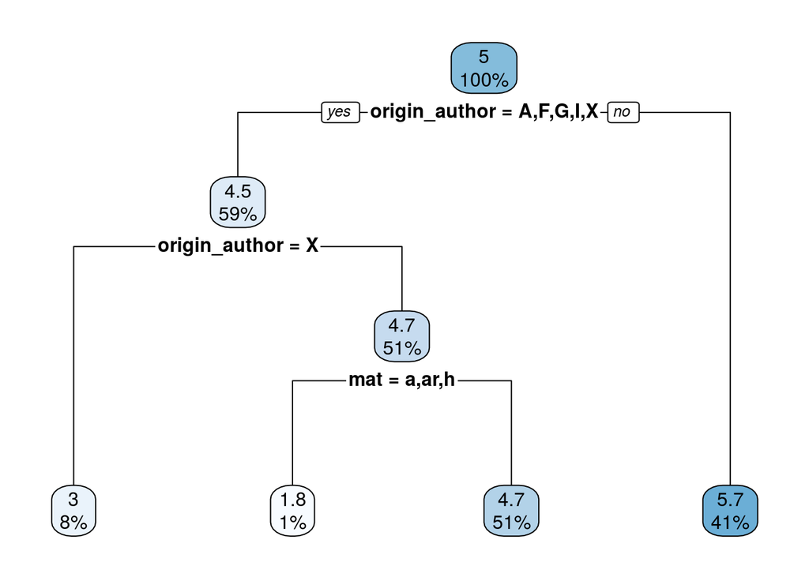

```r
# You could use this plot to predict too:
rpart.plot(pp_rp_simple)
```

How does this compare to a prediction from a linear model? Which model would be considered ‘better’? Can you improve it by modify the rpart controls?

```r
pp_lm_simple <- lm(logprice ~ origin_author + school_pntg + mat , data = pp)

augment(pp_lm_simple, newdata = new_painting)
```

```
## # A tibble: 1 x 4
##   origin_author school_pntg mat   .fitted
##   <chr>         <chr>       <chr>   <dbl>
## 1 X             X           c        3.37
```